# **`5. Data Visualization`**

This chapter introduces basic R plotting using the `ggplot2` package. `ggplot2` is a contributed package written by Hadley Wickham, which is an implementation of the *Grammar of Gaphics* by Leland Wilkinson. One can install `ggplot2` via `install.packages("ggplot2")`. The `ggplot2` package offers a wide variety of powerful tools for creating plots of publication quality. It is impossible to go over every single detail about these facilities in a short time frame. This note aims to help one get started, and so only highlights the most important features of `ggplot2` and introduces some basic fundamentals of plotting using it.

Good references for using `ggplot2` include:

1. [ggplot2 website](http://ggplot2.org/) for official documentation.
2. Hadley Wickham’s [ggplot2: Elegant Graphics for Data Analysis](https://www.amazon.com/dp/0387981403/ref=cm_sw_su_dp?tag=ggplot2-20) for more comprehensive introduction.
3. RStudio’s [ggplot2 cheat sheet](https://www.rstudio.com/wp-content/uploads/2015/03/ggplot2-cheatsheet.pdf) for getting started quickly.

This chapter focuses on two most frequently used plotting functions in `ggplot2`: `qplot()` and `ggplot()`.

### **`5.1 qplot()`**

The `qplot()` function is very similar to the basic `plot()` function from the R `base` package but with many (nice if you like them) built-in features. It can be used to create and combine easily different types of plots.

To plot using `qplot()`, the following inputs are necessary:

1. `data`: must be in the form of `data.frame`[^1].
2. `geoms`: lines, points, bars, etc.
3. `aesthetics`: color, size, shape, position, etc.

The following examples illustrate how to plot using `qplot()`:

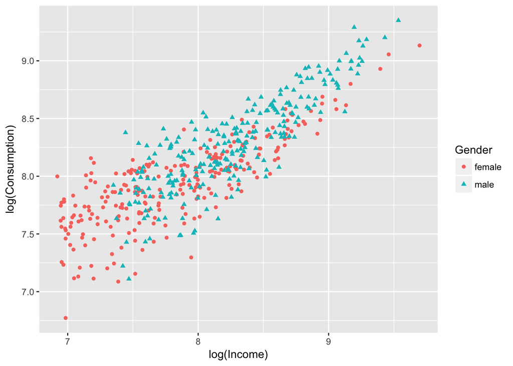

```r
# simulate a data frame
set.seed(1)
Y <- rchisq(250, 2)*1000 + 1000
C <- pmax(rnorm(250, 0, 2)*250 + 0.5*Y + 1500, 0)
G <- 0
data1 <- cbind(G, Y, C)
Y <- rchisq(250, 3)*1000 + 1500
C <- pmax(rnorm(250, 0, 3)*250 + 0.7*Y + 1200, 0)
G <- 1
data2 <- cbind(G, Y, C)
data <- rbind(data1, data2)
Data <- data.frame(data)
attach(Data)
Data$G <- factor(Data$G, levels = c(0, 1), labels = c("female", "male"))
S <- rbinom(500, 1, 0.5)
Data <- cbind(Data, S)
Data$S <- factor(Data$S, levels = c(0, 1), labels = c("NC", "TX"))
names(Data) <- c("Gender", "Income", "Consumption", "State")

# scatterplot using qplot()
library(ggplot2)
qplot(log(Income), log(Consumption),        # specify variables for the x axis and y axis
      data = Data,                          # input data
      geom = c("point"),                    # specify geoms, default for two variables is scatter plot (points)
      color = Gender, shape = Gender)       # add color and shape aesthetics according to the "drv" variable
```

The `facets` argument enables one to split up the data by one or more variables and plot the subsets of data together.

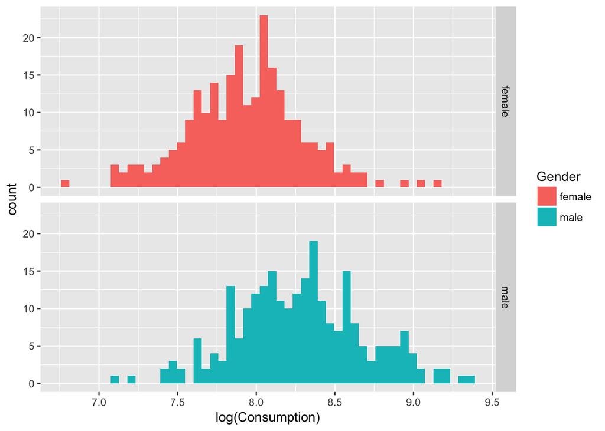

```r
qplot(log(Consumption), data = Data,        # default for one variable is histogram
      fill = Gender, bins = 50,             # fill histograms with different colors according to "drv"
      facets = Gender ~. )                  # facets (conditional plots), row ~ column, panels according to "drv"
```

`qplot()` allows multiple geoms in the same plot.

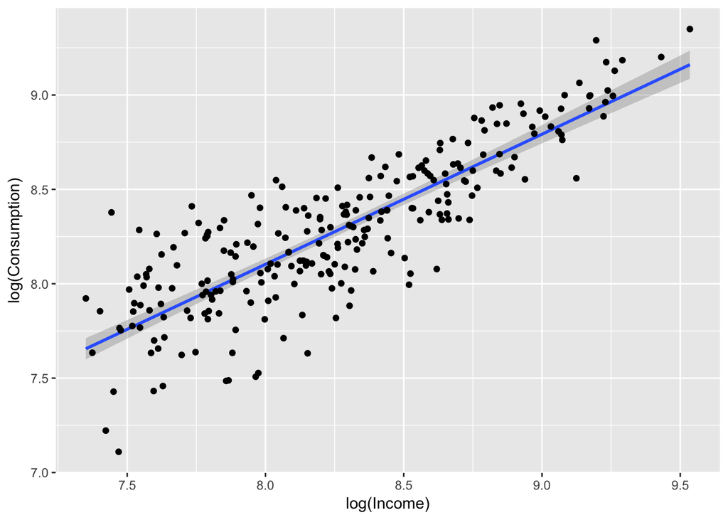

```r
qplot(log(Income), log(Consumption),
      data = Data[Data$Gender == "male",],
      geom = c("smooth", "point"),        # add more geoms
      method = "lm")                      # change method for "smooth" geom, default "loess" -> linear regression
```

One can also add a title to the plot and customize the axis labels.

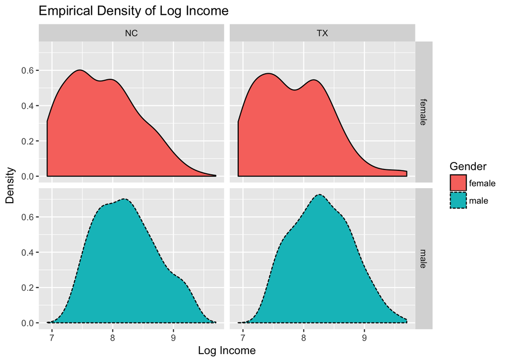

```r
qplot(log(Income), data = Data,
      geom = "density",                          # geom = kernel density
      fill = Gender,
      linetype = Gender,
      facets = Gender ~ State ,
      main = "Empirical Density of Log Income",  # add title
      xlab = "Log Income",                       # change labels of x axis and y axis
      ylab = "Density")
```

`qplot()` is a convenient plotting tool which can do adequately good job quickly in most circumstances, but `ggplot()` is the core function of `ggplot2` and is much more flexible (and so capable) than `qplot()`.

### **`5.2 ggplot()`**

Plots are built layer-by-layer using `ggplot()`. A general plotting procedure includes the following steps:

1. Input data: must be a data frame.
2. Set up aesthetic mappings: describe how variables in the data are mapped to aesthetics of geoms.
3. Add geoms: geometric objects include point (`geom_point()`), line (`geom_line()`), histogram (`geom_histogram()`), etc[^2].
4. Define facets (`facet_grid()`): a matrix of panels defined by row and column faceting variables.
5. Lay out statistics (`stat_function()`): statistical transformations like fitted line, quantile, density. etc.
6. Modify global setttings (`theme()`): legend, backgrounds, fonts, etc.
7. Annotate the plot: add small annotations (e.g., text labels, comment) using `labs()`, `annotate()`, etc.
8. Modify scale properties (e.g., `scale_y_continuous()`): commonly used scale transformation like $\log(x)$ and $1/x$, etc.

Let’s first prepare the data that will be used in plotting and then illustrate how to implement `ggplot()`.

```r
library(readr)
library(dplyr)
setwd("/Users/ouyangfu/Dropbox/Teaching/financial econometrics/2018/data") # set working directory (Mac OS)
sp500m <- read_csv("sp500month.csv")  %>%                                  # read S&P500 monthly data
          select(Date, `Adj Close`) %>%                                    # keep only "date" and "adj close"
          rename(index = `Adj Close`)                                      # rename "adj close" -> "price"
sp500m <- arrange(sp500m, Date)                                            # sort data according to "date"
sp500m <- filter(sp500m, Date >= as.Date("1990-01-01"))                    # keep only post-1990 data
sp500d <- read_csv("sp500day.csv") %>%
          select(Date, `Adj Close`) %>%
          rename(index = `Adj Close`)
sp500d$Date <- as.Date(strptime(as.character(sp500d$Date), "%m/%d/%Y"))    # change the date-time format
sp500d <- arrange(sp500d, Date)
sp500d <- filter(sp500d, Date >= as.Date("1990-01-01"))
vix <- read_csv("vix.csv") %>%
       select(Date, `Adj Close`) %>%
       rename(vix = `Adj Close`)
vix <- arrange(vix, Date)
vix <- filter(vix, Date >= as.Date("1990-01-01"))
dailyData <- inner_join(sp500d, vix, by = "Date")                          # merge sp500d and vix data by "date"
dailyData <- mutate(dailyData,                                             # create new variables
                    lvix = lag(vix, n = 1L),                               # lagged vix
                    lindex = lag(index, n = 1L),                           # lagged S&P500 index
                    Dvix = vix - lvix,                                     # changes in vix
                    logRindex = log(index/lindex))                         # log returns of S&P500 index
sp500m <- mutate(sp500m,
                 lindex = lag(index, n = 1L),
                 logRindex = log(index/lindex),
                 Window = Date >= as.Date("2002-07-01"))
sp500m$Window <- factor(sp500m$Window, levels = c(FALSE, TRUE),
                        labels = c("Before 7/1/2002", "After 7/1/2002"))
```

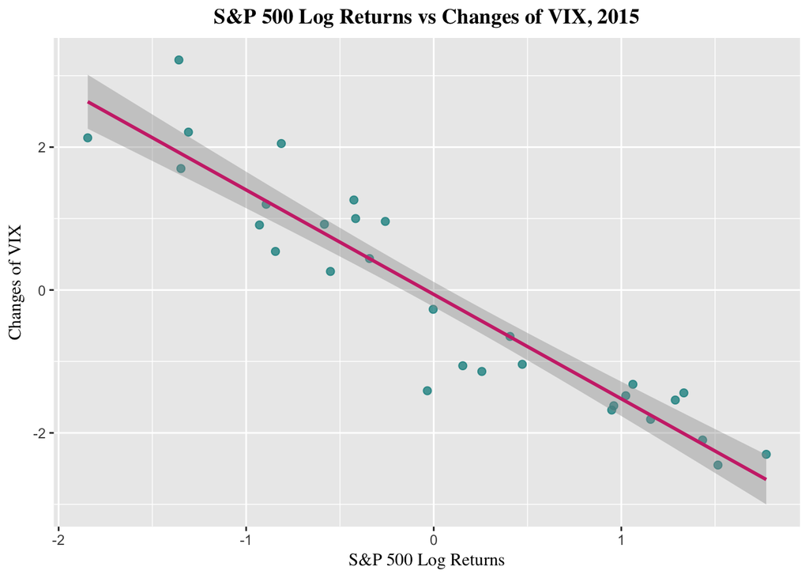

```r
scatterplot <- ggplot(subset(dailyData, Date >= as.Date("2015-01-01")),    # set up ggplot with data and aes
                      aes(logRindex*100, Dvix)) +
  geom_point(alpha = .75, size = 2, color = "cyan4") +                     # add "point" geom and modify it
  labs(title = "S&P 500 Log Returns vs Changes of VIX, 2015",              # add title and axis labels
       x = "S&P 500 Log Returns", y = "Changes of VIX") +
  geom_smooth(method = "lm", level = 0.9, color = "violetred3") +          # add "line" geom and modify it
  theme(axis.title = element_text(family = "serif"),
        plot.title = element_text(hjust = 0.5, family = "serif",
                                  face = "bold"))                          # modify theme characteristics
print(scatterplot)
```

One can add $\LaTeX$ elements to the plot using the `TeX()` function in the `latex2exp` package.

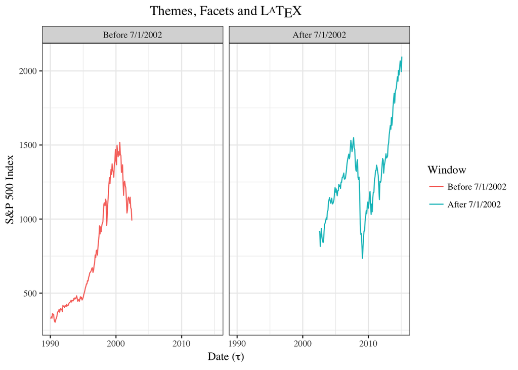

```r
library(latex2exp)
g <- ggplot(sp500m, aes(Date))
g +
  geom_line(aes(y = index, color = Window), size = 0.5) +
  theme_bw(base_family = "serif") +                             # change theme background and font
  theme(plot.title = element_text(hjust = 0.5,
                                  face = "bold")) +             # modify theme characteristics
  facet_grid(. ~ Window) +                                      # add panels, see facet_wrap() also
  labs(title = TeX("Themes, Facets and $\\LaTeX$")) +           # add title
  labs(y = "S&P 500 Index", x = TeX("Date ($\\tau$)"))          # customize labels
```

One can easily arrange multiple ggplots on the same page using the `ggarrange()` function in the `ggpubr` package[^3].

```r
histogram1 <- ggplot(dailyData, aes(logRindex)) +
  geom_histogram(aes(y = ..density..), bins = 100, color="white",
                 fill="dodgerblue3",
                alpha = 0.75, size = 0.1) +
  stat_function(fun = dnorm, color = "darkred", size = 0.5,     # add stats: theoretical pdf
                args = list(mean = mean(dailyData$logRindex,
                                        na.rm = T),
                            sd = sd(dailyData$logRindex,
                                    na.rm = T))) +
  labs(title = "Histogram and Kernel Density of Daily Data",
       x = "Daily Data", y = "Density") +
  theme(axis.title = element_text(family = "serif", size = 9),
        plot.title = element_text(hjust = 0.5, family = "serif",
                                  size = 11))
```

```r
histogram2 <- ggplot(sp500m, aes(logRindex)) +
  geom_histogram(aes(y = ..density..), bins = 80, color="white",
                 fill="seagreen4",
                 alpha = 0.75, size = 0.1) +
  stat_function(fun = dnorm, color = "darkred", size = 0.5,
                args = list(mean = mean(sp500m$logRindex,
                                        na.rm = T),
                            sd = sd(sp500m$logRindex,
                                    na.rm = T))) +
  labs(title = "Histogram and Kernel Density of Monthly Data",
       x = "Monthly Data", y = "Density") +
  theme(axis.title = element_text(family = "serif", size = 9),
        plot.title = element_text(hjust = 0.5, family = "serif",
                                  size = 11))
```

```r
y <- quantile(dailyData$logRindex, c(0.25, 0.75), na.rm = T)
x <- qnorm(c(0.25, 0.75))
slope <- diff(y)/diff(x)
int <- y[1] - slope*x[1]
QQ1 <- ggplot(dailyData, aes(sample = logRindex)) +
  geom_qq(alpha = 0.5, size = 1, color = "dodgerblue3") +
  geom_abline(intercept=int, slope=slope, color = "darkred", size = 1/2) +
  labs(title = "Q-Q Plot of Daily Data",
       x = "Normal Quantile", y = "Quantile of Daily Data") +
  theme(axis.title = element_text(family = "serif", size = 9),
        plot.title = element_text(hjust = 0.5, family = "serif",
                                  size = 11))
```

```r
y <- quantile(sp500m$logRindex, c(0.25, 0.75), na.rm = T)
x <- qnorm(c(0.25, 0.75))
slope <- diff(y)/diff(x)
int <- y[1] - slope*x[1]
QQ2 <- ggplot(sp500m, aes(sample = logRindex)) +
  geom_qq(alpha = 0.5, size = 1, color = "seagreen4") +
  geom_abline(intercept=int, slope=slope, color = "darkred", size = 1/2) +
  labs(title = "Q-Q Plot of Monthly Data",
       x = "Normal Quantile", y = "Quantile of Monthly Data") +
  theme(axis.title = element_text(family = "serif", size = 9),
        plot.title = element_text(hjust = 0.5, family = "serif",
                                  size = 11))
```

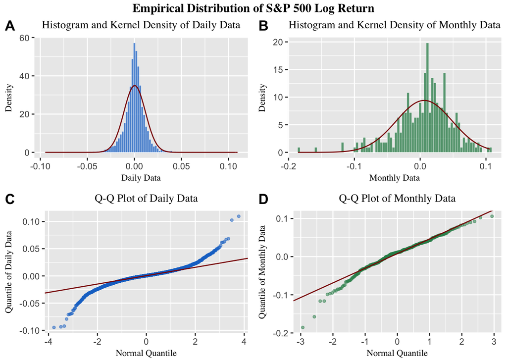

```r
library(ggpubr)
figMatrix <- ggarrange(histogram1, histogram2, QQ1, QQ2,
                       labels = c("A", "B", "C","D"),
                       ncol = 2, nrow = 2)
annotate_figure(figMatrix,
                top = text_grob("Empirical Distribution of S&P 500 Log Return",
                                face = "bold", size = 12,
                                family = "serif"))
```

The following example shows how to modify legend, highlight points, add texts and a second y-axis (with different scale from the first one) in a ggplot.

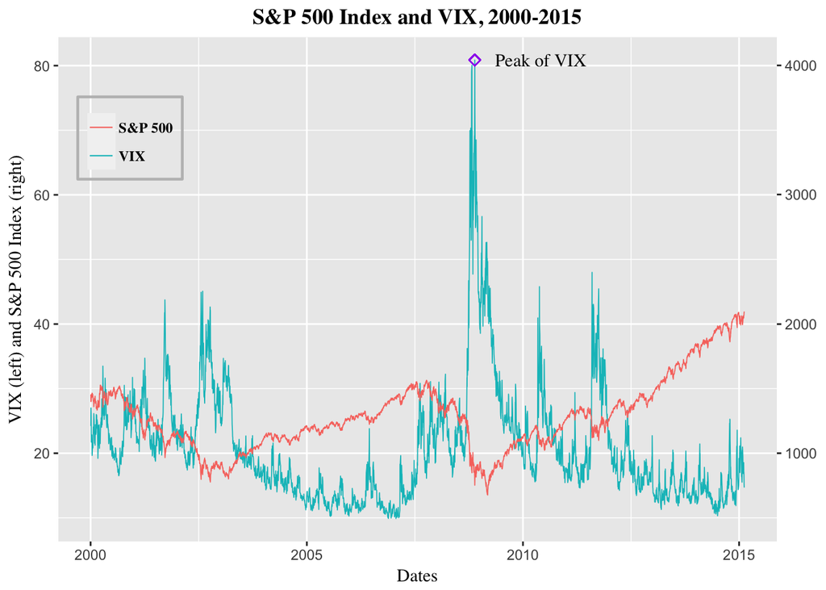

```r
fig <- ggplot(subset(dailyData, Date >= as.Date("2000-01-01")),
                aes(Date)) +
  geom_line(aes(y = vix, color = "VIX"), size = 0.3) +
  geom_line(aes(y = index/50, color = "S&P 500"), size = 0.3) +
  geom_point(y = max(dailyData$vix),
             aes(dailyData$Date[max(dailyData$vix) == dailyData$vix]), # highlight a point
             colour = "purple", size = 2, shape = 5) +
  annotate("text", family = "serif",                                   # add texts
           x = as.Date("2010-06-01"),
           y = max(dailyData$vix), label = "Peak of VIX") +
  labs(title = "S&P 500 Index and VIX, 2000-2015",
       x = "Dates", y = "VIX (left) and S&P 500 Index (right)") +
  theme(axis.title = element_text(family = "serif"),
        plot.title = element_text(hjust = 0.5, family = "serif",
                                  face = "bold"),
        legend.position = c(0.1, 0.8),                                 # add legend
        legend.title = element_blank(),
        legend.background = element_rect(fill=alpha("grey", 0),
                                         color = "grey", size = 0.8,
                                         linetype="solid"),
        legend.text = element_text(family = "serif", face = "bold"),
        legend.key = element_rect(color = "transparent")) +
  scale_y_continuous(sec.axis = sec_axis(~.*50))                       # add the second y-axis
print(fig)
```

[^1]: If factors are used to indicate subsets of the data, they should be properly labeled for being used in `qplot()`.
[^2]: Each `geom` function has its own options for aesthetics.
[^3]: `ggpubr` provides many other easy-to-use functions for creating and customizing `ggplot2`-based publication ready plots.